# 王厚骅-PB25081529-第三次作业

##### 王厚骅-$\text{PB25081529}$-第三次作业

#### 作业 1

> 考虑一个简单的蛋白质合成与降解系统．蛋白质 $\text{P}$ 以恒定速率 $k_\mathrm{s}$ 合成，但其降解过程由一种蛋白酶催化，遵循米氏动力学： $$\frac{\mathrm{d}P}{\mathrm{d}t} = k_\mathrm{s} - \frac{V_{\max} \cdot P}{K_\mathrm{m} + P}$$
> 1. 稳态解析：求出系统达到稳态时蛋白质浓度 $P^*$ 的代数表达式．

**【解】** 达到稳态，即 $\frac{\mathrm{d}P}{\mathrm{d}t} = 0$，解得 $P^* = \boxed{\frac{k_\mathrm{s}\cdot K_\mathrm{m}}{V_{\max}-k_\mathrm{s}}}$.

> 2. 存在性分析：讨论在什么条件下（$k_\mathrm{s}$ 与 $V_{\max}$ 的关系），该系统能维持一个正值的稳定稳态？如果 $k_\mathrm{s} > V_{\max}$，浓度会发生什么变化？

**【解】** 显然当且仅当 $k_\mathrm{s} < V_{\max}$ 时，存在有限正值 $P^*$，即只有此时才存在正值稳态；而 $P < P^*$ 时 $\frac{\mathrm{d}P}{\mathrm{d}t} > 0$ 即 $P$ 在增大， $P > P^*$ 时 $\frac{\mathrm{d}P}{\mathrm{d}t} < 0$ 即 $P$ 在减小，故知该稳态是稳定的．综上，**该系统能维持一个正值的稳定稳态，当且仅当 $k_\mathrm{s} < V_{\max}$**．

如果 $k_\mathrm{s} > V_{\max}$，则 $\frac{\mathrm{d}P}{\mathrm{d}t}$ 恒正，**浓度将一直增加**．

> 3. 参数影响：若增加合成速率 $k_\mathrm{s}$，稳态浓度 $P^*$ 是线性增加还是非线性增加？

**【解】** $P^* = \frac{k_\mathrm{s}\cdot K_\mathrm{m}}{V_{\max}-k_\mathrm{s}} = \frac{K_\mathrm{m}}{\frac{V_{\max}}{k_\mathrm{s}} - 1}$，显然随 $k_\mathrm{s}$ 增加，稳态浓度是**非线性增加**．

#### 作业 2

> 分析体系：

[figure not shown]

> $\frac{\mathrm{d}R}{\mathrm{d}t} = k_0E_P(R)+k_1S-k_2R,\ E_P(R) = G(k_3R,k_4, J_3, J_4)$.
> 1. 初始条件 $k_0 = 0.4,\ k_1 = 0.01,\ k_2 = k_3 = 1,\ k_4 = 0.2,\ J_3 = J_4 = 0.05$，针对 $S = 0, 8, 10$，分别用 $\text{R}$ 生成速率和降解速率对 $R$ 作图，并标出与稳态对应的点，区分稳定与不稳定的稳态；计算 $R$ 稳态随 $S$ 的变化并作图．

**【解】** 代码和图如下．

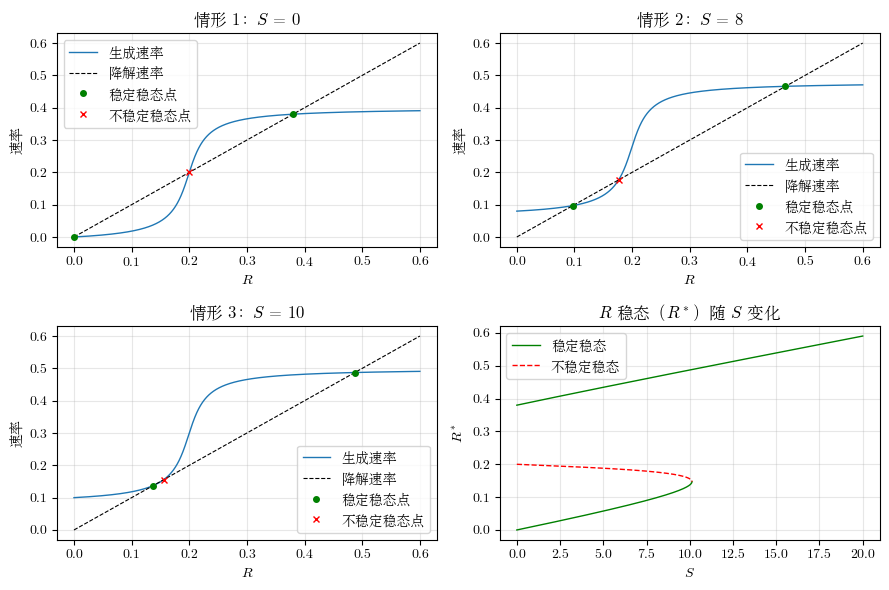

```python
import math
import numpy as np
from matplotlib import pyplot as plt
from matplotlib.gridspec import GridSpec
from scipy.optimize import fsolve

# pyplot 后端参数设置
plt.rcParams['mathtext.fontset'] = 'cm' # Computer Modern
plt.rcParams['font.family'] = 'serif'
plt.rcParams['font.serif'].insert(0, 'FandolSong')
plt.rcParams['axes.unicode_minus'] = False

# 模型参数初始化
S_values = [0, 8, 10]
k_0 = 0.4
k_1 = 0.01
k_2 = 1
k_3 = 1
k_4 = 0.2
J_3 = 0.05
J_4 = 0.05

# 图幅和分栏初始化
plt.figure(figsize=(9, 6))
gs = GridSpec(2, 2)

# R 取值点
R = np.linspace(0, 0.6, 100000)

# G 函数
def G(u: np.ndarray, v: float, J: float, K: float) -> np.ndarray:
    t1 = v - u
    t2 = u * K
    t3 = t1 + t2 + v * J
    return (t2 * 2) / (t3 + np.sqrt(t3 * t3 - 4 * t1 * t2))

def G_single(u: float, v:float, J: float, K: float) -> float:
    t1 = v - u
    t2 = u * K
    t3 = t1 + t2 + v * J
    return (t2 * 2) / (t3 + math.sqrt(t3 * t3 - 4 * t1 * t2))

# 单点求 v_gen 值
def v_gen(x: float, S: float) -> float:
    return k_0 * G_single(x * k_3, k_4, J_3, J_4) + k_1 * S

# ------ 绘制三种 S 取值时的生成降解速率图 ------

# 逐点求值
def vs_gen(R: np.ndarray, S: float) -> np.ndarray:
    return k_0 * G(R * k_3, k_4, J_3, J_4) + k_1 * S

def calc(S: float) -> tuple[np.ndarray, np.ndarray]:
    return (vs_gen(R, S), k_2 * R)

# 判断稳态稳定性
def is_stable(x: np.float64, S: float) -> int:
    h = 1e-6
    return 1 if (v_gen(x + h, S) - v_gen(x, S)) < k_2 * h else 0

# 绘制稳态点
def draw_ss(val: np.ndarray, S: float) -> None:
    sss = set(round(root, 3) for root in R[np.fabs(val) < 5e-6])
    ssss = np.array([ss for ss in sss if is_stable(ss, S)])
    nsss = np.array([ss for ss in sss if not is_stable(ss, S)])
    plt.plot(ssss, ssss * k_2, marker='o', color='green', markersize=4,
             label='稳定稳态点', linestyle='none')
    plt.plot(nsss, nsss * k_2, marker='x', color='red', markersize=4,
             label='不稳定稳态点', linestyle='none')

# 分别绘制 3 种情形的图
for i in range(3):
    plt.subplot(gs[i // 2, i % 2])
    S = S_values[i]
    plt.title('情形 {0}：$S$ = {1}'.format(i + 1, S))
    plt.xlabel('$R$')
    plt.ylabel('速率')
    vs_gen_values, vs_deg_values = calc(S)
    plt.plot(R, vs_gen_values, lw=1, label='生成速率')
    plt.plot(R, vs_deg_values, lw=0.8, ls='--', color='k', label='降解速率')
    draw_ss(vs_gen_values - vs_deg_values, S)
    plt.grid(alpha=0.3)
    plt.legend()

# ------ 绘制稳态随 S 变化图 ------

# S 取值点
S_values = np.linspace(0, 20, 10000)

# 求解起点
rs1 = rc1 = 0
rs2 = rc2 = 0.2
rs3 = rc3 = 0.37
root_count = 3

# 稳态点
ssss1 = list()
ssss2 = list()
nsss = list()

# 步进求解
for S in S_values:
    def f(x: np.ndarray) -> np.ndarray:
        return vs_gen(x, S) - k_2 * x
    if root_count == 3:
        rc1 = fsolve(f, rs1, full_output=False)[0]
    if root_count >= 2:
        rc2 = fsolve(f, rs2, full_output=False)[0]
    rc3 = fsolve(f, rs3, full_output=False)[0]
    if root_count == 3 and np.fabs(rc1 - rc2) < 1e-5:
        root_count = 2
    elif root_count == 2:
        root_count = 1
    if root_count == 3:
        ssss1.append((S, rc1))
        ssss2.append((S, rc3))
        nsss.append((S, rc2))
    elif root_count == 2:
        ssss1.append((S, rc2))
        ssss2.append((S, rc3))
    else:
        ssss2.append((S, rc3))
    rs1, rs2, rs3 = rc1, rc2, rc3

ssss1 = np.array(ssss1)
ssss2 = np.array(ssss2)
nsss = np.array(nsss)

# 绘图
plt.subplot(gs[1, 1])
plt.title('$R$ 稳态（$R^*$）随 $S$ 变化')
plt.xlabel('$S$')
plt.ylabel('$R^*$')
plt.plot(ssss1[:, 0], ssss1[:, 1], lw=1, color='green', label='稳定稳态')
plt.plot(ssss2[:, 0], ssss2[:, 1], lw=1, color='green')
plt.plot(nsss[:, 0], nsss[:, 1], lw=1, color='red', ls='--', label='不稳定稳态')
plt.grid(alpha=0.3)
plt.legend()
plt.tight_layout()
```

> 2. 随机选择 $5$ 组初始条件，用数值积分得到 $R$ 随时间变化轨迹并作图．

**【解】** 代码和图如下．

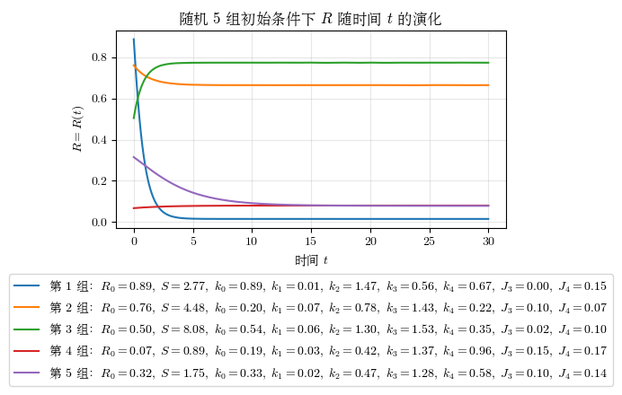

```python
from scipy.integrate import solve_ivp

# 随机引擎
rng = np.random.default_rng()

# 加上异常（来自不合理随机数值）捕获的 G 函数
def G_safe(u: np.ndarray, v:float, J: float, K: float) -> np.ndarray | None:
    try:
        t1 = v - u
        t2 = u * K
        t3 = t1 + t2 + v * J
        return (t2 * 2) / (t3 + np.sqrt(t3 * t3 - 4 * t1 * t2))
    except:
        print('!: u = {0}, v = {1}, J = {2}, K = {3}'.format(
            u, v, J, K))

# ODE 初始化
def dRdt(t, R):
    return k_0 * G_safe(k_3 * R, k_4, J_3, J_4) + k_1 * S - k_2 * R

t_span = (0, 30)
t_eval = np.linspace(0, 30, 10000)

# 随机生成 5 组初始条件，数值积分并绘制轨迹
for i in range(5):
    k_0, k_1, k_2, k_3, k_4, J_3, J_4, S, R_0 = rng.random(9) * np.array(
        [1, 0.1, 2, 2, 1, 0.2, 0.2, 10, 1])
    sol = solve_ivp(dRdt, t_span=t_span, t_eval=t_eval, y0=[R_0])
    label = f'第 ${i+1}$ 组：$R_0={R_0:.2f},\\ S={S:.2f},\\ k_0={k_0:.2f},\\ \
              k_1={k_1:.2f},\\ k_2={k_2:.2f},\\ k_3={k_3:.2f},\\ \
              k_4={k_4:.2f},\\ J_3={J_3:.2f},\\ J_4={J_4:.2f}$'
    plt.plot(sol.t, sol.y[0], label=label)

# 图参数设置
plt.title('随机 $5$ 组初始条件下 $R$ 随时间 $t$ 的演化')
plt.xlabel('时间 $t$')
plt.ylabel('$R = R(t)$')
plt.legend(bbox_to_anchor=(0.5, -0.2), loc='upper center')
plt.grid(alpha=0.3)
plt.tight_layout()
```

> 3. 用恰当文字解释体系的不可逆性．

**【解】** 从 1 题“$R$ 稳态（$R^*$）随 $S$ 变化”图中可见：当初始 $R$ 在低支时，随 $S$ 增加，$R$ 将沿低支向右移动，直到达到低支消失点（*鞍结分叉点*）时突跃到高支，并继续沿高支向右运动；而接下来随 $S$ 减少，$R$ 将一直沿高支向左运动，由于高支在 $S \ge 0$ 范围内始终为稳定稳态，故 $R$ 将永远不会再回到低支．故知，若初始 $R$ 在低支某处，只要 $S$ 增大到超过一定阈值（鞍结分叉点对应 $S$ 值）后再减小，则 $R$ 将永远不会再回到初始状态．此即体系不可逆性．

#### 作业 3

> 某合成生物学元件构成了下面体系，其简化动力学方程如下： $$\begin{cases} \frac{\mathrm d R}{\mathrm d t} = \frac{\alpha}{1+E^2} - \delta R\\ \frac{\mathrm d E}{\mathrm d t} = \frac{\alpha}{1+R^2} - \delta E \end{cases}$$

> 已知降解率 $\delta = 1$．
> 1. 零增长曲线：请写出该系统的两条零增长线方程（即 $\mathrm d R / \mathrm d t = 0$ 和 $\mathrm d E / \mathrm d t = 0$）．

**【解】** 令 $\mathrm d R / \mathrm d t = 0$ 得 $\boxed{R = \frac{\alpha}{1+E^2}}$，令 $\mathrm d E / \mathrm d t = 0$ 得 $\boxed{E = \frac{\alpha}{1+R^2}}$．

> 2. 对称稳态分析：当 $R=E$ 时，系统存在一个对称平衡点．请代入参数证明，当 $\alpha = 3$ 时，该平衡点大约在 $R^* \approx 1.3$ 处．

**【证明】** $\alpha = 3,\ R = E$ 时有 $R = \frac3{1+R^2}$，解之即得 $R\approx 1.3$．$\square$

> 3. 稳定性判断：利用相平面分析的方法，思考：如果起始状态下 $R = 2,\ E = 0.1$，系统最终会落入对称平衡点，还是会偏向于其中一个变量（即产生双稳态）？

**【解】** 联立两零增长线方程可得 $(R-E)(1-RE) = 0$，则有 $R = E$ 和 $RE = 1$ 两种解．

令 $R = E$ 有 $R^3 + R - \alpha = 0$，$\forall \alpha \in \mathbb R$ 该一元三次方程总存在唯一根，故对称平衡点总存在；令 $RE = 1$ 有 $\alpha = R + \frac1R \ge 2$，且 $\alpha = 2$ 时 $R = E = 1$，故非对称平衡点存在当且仅当 $\alpha > 2$．

分别对 $\alpha \le 2$ 和 $\alpha > 2$ 进行相平面分析．借助数学分析和数值模拟，可知：$\alpha \le 2$ 时，唯一平衡点（对称平衡点）为稳定点，无论初始条件如何，系统总会被吸入该点．$\alpha > 2$ 时在对称平衡点处发生了两零增长线相对方位的反转（指相对 $\alpha \le 2$ 时），而原相对方位关系移至两非对称平衡点处，此时对称平衡点为鞍点，只有其稳定流形 $R = E$ 直线上的状态才将向该点演化；两非对称平衡点均为稳定点，且其吸引域以前述鞍点稳定流形 $R = E$ 直线为界．

故知：$\alpha \le 2$ 时，系统最终会落入对称平衡点；$\alpha > 2$ 时，由于 $(R = 2,\ E = 0.1)$ 位于下侧稳定点的吸引域中，该初始条件下系统会偏向变量 $R$（另一稳定点偏向 $E$），系统本身具有双稳态性质．

*分析时借助了向量场图，以下是 DeepSeek 为我生成的绘制向量场图的代码（有一定修改），及其绘出的图．*

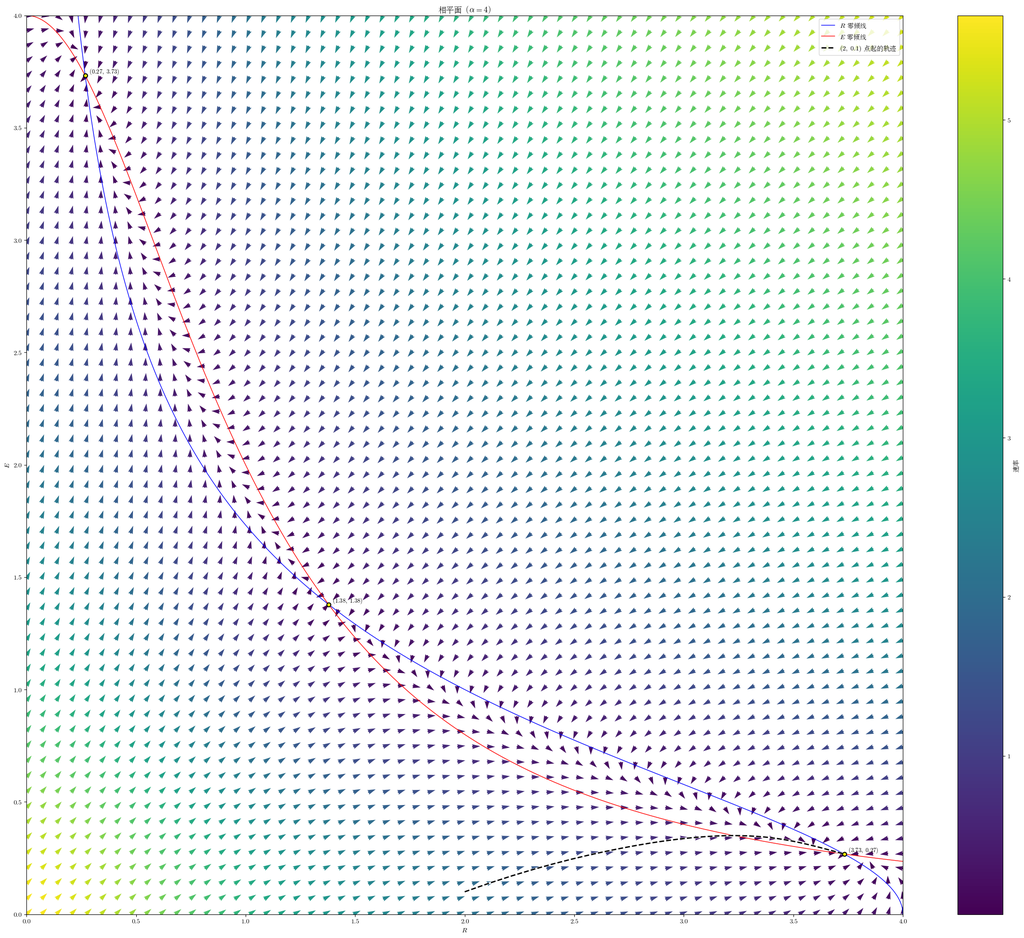

```python
import numpy as np
import matplotlib.pyplot as plt
from scipy.optimize import fsolve
from scipy.integrate import solve_ivp

α = 4

# 定义右端函数（向量形式，便于 fsolve）
def system(y):
    R, E = y
    dR = α / (1 + E**2) - R
    dE = α / (1 + R**2) - E
    return [dR, dE]

# ---------- 1. 向量场 ----------
R = np.linspace(0, 4, 60)
E = np.linspace(0, 4, 60)
RR, EE = np.meshgrid(R, E)
U = α/(1+EE**2) - RR
V = α/(1+RR**2) - EE
N = np.sqrt(U**2 + V**2)
U_norm = U/N
V_norm = V/N

plt.figure(figsize=(24,20))
plt.quiver(RR, EE, U_norm, V_norm, N, cmap='viridis', width=0.002)
plt.colorbar(label='速率')

# ---------- 2. 零倾线 ----------
# R零倾线: R = α/(1+E^2)
E_plot = np.linspace(0, 4, 300)
R_null = α / (1 + E_plot**2)
plt.plot(R_null, E_plot, 'b-', lw=1, label=r'$R$ 零倾线')

# E零倾线: E = α/(1+R^2)
R_plot = np.linspace(0, 4, 300)
E_null = α / (1 + R_plot**2)
plt.plot(R_plot, E_null, 'r-', lw=1, label=r'$E$ 零倾线')

# ---------- 3. 平衡点（交点）----------
# 方法：在网格上找近似交点，然后用fsolve精确化
approx_R = np.linspace(0, 4, 50)
approx_E = np.linspace(0, 4, 50)
roots = set()
for r0 in approx_R:
    for e0 in approx_E:
        # 粗略判断是否靠近交点
        if abs(α/(1+e0**2)-r0) < 0.3 and abs(α/(1+r0**2)-e0) < 0.3:
            sol = fsolve(system, [r0, e0])
            r, e = sol[0], sol[1]
            if 0 <= r <= 4 and 0 <= e <= 4 and abs(system(sol)[0]) < 1e-6:
                roots.add((round(r,4), round(e,4)))
for r, e in roots:
    plt.plot(r, e, 'ko', markersize=6, markeredgewidth=1.5,
             markerfacecolor='yellow', zorder=5)
    plt.text(r, e, f'  $({r:.2f},\\ {e:.2f})$', fontsize=9,
             verticalalignment='bottom')

# ---------- 4. （可选）叠加一条从(2,0.1)出发的轨迹 ----------
def dydt(t, y):
    R, E = y
    return [α/(1+E**2)-R, α/(1+R**2)-E]
sol = solve_ivp(dydt, [0, 30], [2, 0.1], t_eval=np.linspace(0,30,500))
plt.plot(sol.y[0], sol.y[1], 'w', lw=3)  # 白线醒目
plt.plot(sol.y[0], sol.y[1], 'k--', lw=2, label='$(2,\\ 0.1)$ 点起的轨迹')                     # 黑色虚线

# ---------- 装饰 ----------
plt.xlim(0,4)
plt.ylim(0,4)
plt.xlabel('$R$')
plt.ylabel('$E$')
plt.title(f'相平面（$\\alpha={α}$）')
plt.legend()
plt.tight_layout()
plt.show()
```

> 4. 参数灵敏度分析：若 $\alpha$ 极小（如 $\alpha = 0.1$），该开关功能是否还会存在？请简述理由．

**【解】** 不会存在．由前述结论显见，只有 $\alpha > 2$ 时，系统最终演化结果才依初始状态不同而分化到两稳定状态（不含鞍点），这两状态分别对应 $R$ 与 $E$ 不同的高低对比关系，此时表现出开关功能；而 $\alpha \le 2$ 时，系统演化结果唯一，与各种条件无关，此时开关功能消失．

#### 作业 4

> 在生化网络中，一个酶 $\text{E}$ 往往可以催化多个底物．假设底物 $\text{S}$ 被酶 $\text{E}$ 催化生成产物，其动力学遵循 $v = \frac{V_{\max}\cdot S}{K_\text{m}+S}$．现在引入一个抑制剂 $\text{I}$（例如某种药物或竞争性代谢产物），它会抢夺酶的活性位点，但不被催化．此时酶的表观半饱和常数变为 $K'_\text{m} = K_\text{m}\left(1 + \frac{I}{K_\text{I}}\right)$，其中 $K_\text{I}$ 是抑制常数．
> 1. 请写出存在抑制剂 $\text{I}$ 时，产物生成速率 $v$ 的完整表达式．

**【解】** 以表观半饱和常数代原式中的半饱和常数，即得 $v = \frac{V_{\max}\cdot S}{K'_\text{m}+S} = \boxed{\frac{V_{\max}\cdot S}{K_\text{m}\left(1 + \frac{I}{K_\text{I}}\right)+S}}$.

> 2. 当底物浓度 $S \to +\infty$ 时，抑制剂 $\text{I}$ 是否还能有效降低反应速率？请从数学角度解释原因．

**【解】** 显然 $\lim\limits_{S\to+\infty}v(S) = V_{\max}$，反应速率达到理论最大速率，即此时**抑制剂不能有效降低反应速率**．

> 3. 若 $K_\text{m} = 2\mathrm{\ \mu M},\ I = 3\mathrm{\ \mu M},\ K_\text{I} = 1\mathrm{\ \mu M}$，为了使反应速率达到 $V_{\max}$ 的一半，底物 $\text{S}$ 需要多大浓度？

**【解】** 由 1 题得到的表达式列出方程，解之即得 $S = \boxed{8\mathrm{\ \mu M}}$.

#### 作业 5

> 讲义中提到了别构效应和 $\text{Hill}$ 方程．考虑一个受体 $\text{R}$ 与配体 $\text{L}$ 结合的过程．如果受体具有单体结合特征，$n = 1$；如果具有强烈的协同性（别构调节），其结合率 $Y$ 遵循： $$Y = \frac{L^n}{K_\mathrm{d}+L^n}$$ 其中 $n$ 为 $\text{Hill}$ 系数．
> 1. 请描述当 $n = 1$ 与 $n = 4$ 时，结合曲线 $Y(L)$ 在形态上的主要区别．

**【解】** $n = 1$ 时为双曲线，曲线单调递增且斜率单调递减（上凸）；$n = 4$ 时为 $\text{Sigmoid}$ 线，曲线单调递增，先下凸后上凸，在拐点附近从较低值急剧增长到接近饱和，远离拐点处则增长缓慢，具有明显的“开关”特征．

> 2. 计算从 $Y = 0.1$ 到 $Y = 0.9$ 所需的配体浓度倍数（即 $L_{90}/L_{10}$）．

**【解】** $L(Y) = \sqrt[n]{\frac{K_\mathrm{d} Y}{1-Y}}$，则 $L_{90}/L_{10} = \frac{L(0.9)}{L(0.1)} = \boxed{\sqrt[n]{81}}$.

> 3. 证明当 $n$ 越大时，这个倍数越小，并阐述这对细胞“开关响应”的意义．

**【解】** 证明：显而易见．$\square$

意义：具有强协同性作用的受体对配体浓度变化敏感的跳变点低且跳变范围窄，即表现出更灵敏和干净的开关特征，从物理上赋予了细胞逻辑门调控的能力．这有利于细胞通过灵敏的开关响应对自身代谢活动实现精细的“数字信号”调控，有利于增强细胞对背景信号噪声的容忍；另外与正反馈机制相耦合可以形成双稳态系统，从而一定程度上赋予细胞对环境信号的记忆能力．